# The effects of Loan Characterics on Borrower's APR

## by Joshua Alabi

## Investigation Overview

> In this presentation, some visualizations on loans's characterics will be created to study their relationships/coorelations on borrowers's APR. The characters used are BorrowerAPR, ProsperScore, LoanOriginalAmount, StatedMonthlyIncome.

## Dataset Overview

> The Dataset contains 113,917 loans, each row has infomation on the, loan status, loan amount, borrow's APR, borrowers monthly income, etc. This study will be analyzing factors that could influence borrow's APR by looking at some selected characters and how to relate to borrower's ARP.

## Distribution of BorrowerAPR

> The Observation here is that the lowerest APR is at around 0.0065 and the highested is at around 0.51. Two high counts are found at 0.18 and 0.36.

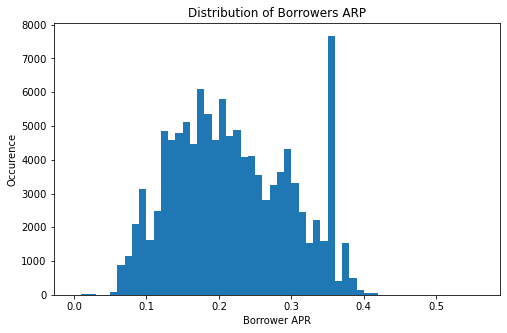

## Coorelation plot between some columns

> There are no obvious strong positive coorelation between the columns selected. The correlation matrix plots helped to preview all possibles variables related on BorrowerAPR we are analyzing. Out of all variables, ProsperScore has stronger negative coorelation with BorrowerAPR. Borrower APR is also negatively correlated with the loan original amount, which mean that the more the loan amount, the lower the borrowers APR.

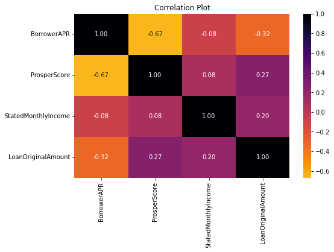

## Effect of Prosper Rating on Borrowers APR and Loan Amount

> The loan amount increases with better rating while borrower APR decreases with better rating. It is also good to note that the relationship between borrower APR and loan amount turns from negative to slightly positive change when the Prosper ratings are increased. This might be as a result of people with A or AA ratings borrowing more money, but people with lower ratings tend to borrow less money, decreasing borrowers APR could encourage them to borrow more.

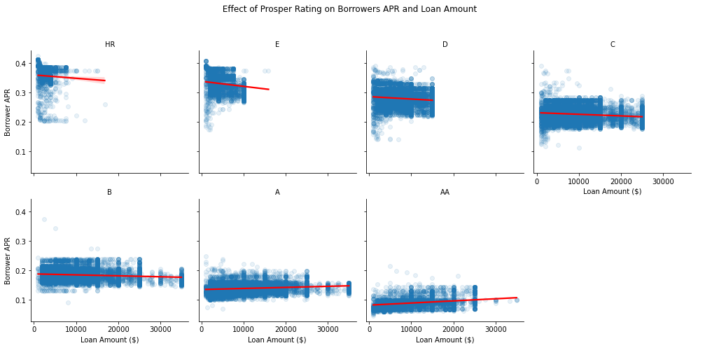